# Lab12

Kwon Yong Chan

2021 2 16

## Lab12. 사례연구

1루를 크게 도는 것과 작게 도는 것 중 어느 방법이 2루에 빨리 도달하는가? paird-t 검정을 통해서 확인해본다. Paired-t 검정을 사용하기 위해서는 자료가 정규분포를 따르는지 여부를 확인해야 한다. 정규성 가정이 의심스러울 경우 순열검정을 사용하면 된다.

```r
library(readxl)
baseball <- read_excel("baseball.xlsx")
View(baseball)
attach(baseball)
t.test(Wide, Narrow, paired = TRUE)
```

```
##
##  Paired t-test
##
## data:  Wide and Narrow
## t = 3.9837, df = 21, p-value = 0.0006754
## alternative hypothesis: true difference in means is not equal to 0
## 95 percent confidence interval:
##  0.03584814 0.11415186
## sample estimates:
## mean of the differences
##                   0.075
```

```r
detach(baseball)
```

# 이표본 t-검정

IMDb 데이터베이스에서 로맨스와 액션 장르 평균 평점비교를 비교하기 위해 액션 영화 32편과 로맨스 영화 36편을 임의로 뽑았다. moderndive 패키지가 설치되어 있어야 한다.

```r
library(moderndive)
movies_sample
```

```
## # A tibble: 68 x 4
##    title                     year rating genre
##    <chr>                    <int>  <dbl> <chr>
##  1 Underworld                1985    3.1 Action
##  2 Love Affair               1932    6.3 Romance
##  3 Junglee                   1961    6.8 Romance
##  4 Eversmile, New Jersey     1989    5   Romance
##  5 Search and Destroy        1979    4   Action
##  6 Secreto de Romelia, El    1988    4.9 Romance
##  7 Amants du Pont-Neuf, Les  1991    7.4 Romance
##  8 Illicit Dreams            1995    3.5 Action
##  9 Kabhi Kabhie              1976    7.7 Romance
## 10 Electric Horseman, The    1979    5.8 Romance
## # ... with 58 more rows
```

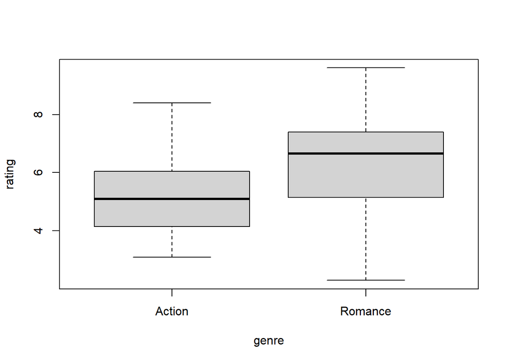

```r
attach(movies_sample)

boxplot(rating~genre)
```

```r
t.test(rating~genre)
```

```
##
##  Welch Two Sample t-test
##
## data:  rating by genre
## t = -2.9059, df = 65.85, p-value = 0.004983
## alternative hypothesis: true difference in means is not equal to 0
## 95 percent confidence interval:
##  -1.766773 -0.327671
## sample estimates:
##  mean in group Action mean in group Romance
##              5.275000              6.322222
```

```r
t.test(rating~genre, var.equal = TRUE)
```

```
##
##  Two Sample t-test
##
## data:  rating by genre
## t = -2.8772, df = 66, p-value = 0.005399
## alternative hypothesis: true difference in means is not equal to 0
## 95 percent confidence interval:
##  -1.7739131 -0.3205314
## sample estimates:
##  mean in group Action mean in group Romance
##              5.275000              6.322222
```

```r
detach(movies_sample)
```

# 3집단 이상 집단에서 평균의 비교

4개 브랜드의 자동차 타이어의 수명을 비교하고자 한다. 자료는 tyre.csv파일로 제공되며 브랜드별로 15개 타이어의 수명이 사용 마일리지로 기록되어 있다. 우리는 브랜드별로 수명의 차이가 있는지 궁금하다.

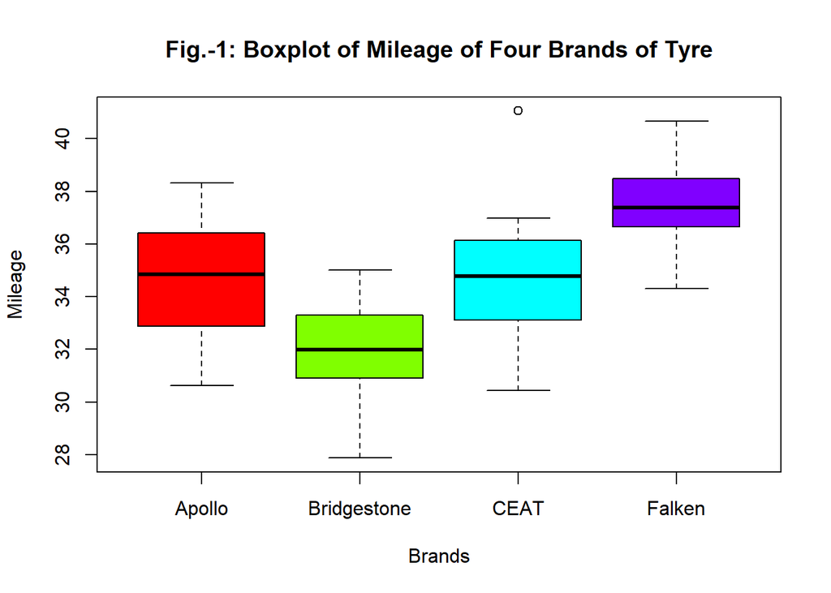

```r
tyre <- read.csv("tyre.csv")
attach(tyre)

boxplot(Mileage~Brands, main = "Fig.-1: Boxplot of Mileage of Four Brands of Tyre", col = rainbow(4))
```

Boxplot으로 살펴본 결과 등분산성 가정은 문제가 없어 보인다. ANOVA에서 F-검정결과는 귀무가설을 기각한다. 즉 브랜드별로 수명의 차이가 있다고 볼 수 있다.

```r
model1 <- aov(Mileage~Brands)
summary(model1)
```

```
##             Df Sum Sq Mean Sq F value   Pr(>F)
## Brands       3  256.3   85.43   17.94 2.78e-08 ***
## Residuals   56  266.6    4.76
## ---
## Signif. codes:  0 '***' 0.001 '**' 0.01 '*' 0.05 '.' 0.1 ' ' 1
```

```r
detach(tyre)
```